# L.A. County Employee Salaries

### 1.0 Introduction

We would like to generate some visualizations for an [L.A. County employee salaries](https://data.lacounty.gov/Operations/LA-County-Employee-Salaries/8rdv-6nb6) dataset that includes county employees’ salaries and benefits for the years 2013-2015. The dataset consists of a little over 300,000 records. We will mainly focus on the most recent data, from 2015.

Start by loading R required libraries we will be using

```r
library(magrittr) # pipe operator %>%
library(ggplot2) # plots
library(rbokeh) # plots
library(readr) # read data frame quickly
library(d3heatmap) # heat maps
```

#### 1.1 Loading the data

```r
la_salaries <- read_csv("LA_County_Employee_Salaries.csv")
#str(salaries)
#for (colname in colnames(salaries)) {str(salaries[colname])}
colnames(la_salaries)
```

```
 [1] "Year"                    "Employee Last Name"      "Employee First Name"
 [4] "Middle Initial"          "Position Title"          "Department"
 [7] "Base Earnings"           "Overtime Earnings"       "Other Earnings"
[10] "Leave Time Payouts"      "Total Earnings"          "Medical, Dental, Vision"
[13] "Retirement Surcharge"    "Pension Contributions"   "Deferred Contributions"
[16] "LTD Life & Medical Tax"  "Other Benefits"          "Total Benefits"
[19] "Total Compensation"      "index"                   "ID Number"
[22] "position type"           "Employee Name"
```

```r
dataset_size <- dim(la_salaries)
cat("\nNumber of observations:", dataset_size[1], "\nNumber of variables:", dataset_size[2])
```

```
Number of observations: 307961
Number of variables: 23
```

#### 1.2 Data munging

##### 1.2.1 Removing unused columns and renaming others

Removing some columns we will not use, such as first and last names. Also, the “index”, and “ID” and “position type” all came in empty. In addition, we will replace the spaces, " “, in the column names with underscore,”_“.

```r
# Removing
to_be_removed <- c("Employee Last Name", "Employee First Name", "Middle Initial",
                   "index", "ID Number", "position type")
for (colname in to_be_removed) {la_salaries[colname] <- NULL}
# Renaming using plyr's rename() to replace " " with "_" in the columns' names
old_names <- c("Base Earnings", "Position Title", "Overtime Earnings", "Other Earnings",
               "Leave Time Payouts", "Total Earnings", "Retirement Surcharge",
               "Pension Contributions", "Deferred Contributions", "Other Benefits",
               "Total Benefits", "Total Compensation", "Employee Name")
new_names <- gsub(" ", "_", old_names, fixed=T)
for (idx in 1:length(old_names))
  {names(la_salaries)[names(la_salaries) == old_names[idx]] <- new_names[idx]}
# Doing a couple by hand
names(la_salaries)[names(la_salaries) == "Medical, Dental, Vision"] <- "Medical_Dental_Vision"
names(la_salaries)[names(la_salaries) == "LTD Life & Medical Tax"] <- "LTD_Life_Medical_Tax"
# Removing the "/" from some departments' names
la_salaries$Department[la_salaries$Department == "Agric Comm/Wts & Measures"] <- "Agric Comm-Wts & Measures"
la_salaries$Department[la_salaries$Department == "Non-Departmental / Unbudgeted"] <- "Non-Departmental - Unbudgeted"
```

##### 1.2.2 Removing dollar signs

Removing the dollar sign from the earnings and benefits columns so R can treat them as numbers rather than strings.

```r
earnings_benefits <- c("Base_Earnings", "Overtime_Earnings", "Other_Earnings", "Leave_Time_Payouts",
                     "Total_Earnings", "Medical_Dental_Vision", "Retirement_Surcharge",
                     "Pension_Contributions", "Deferred_Contributions", "LTD_Life_Medical_Tax",
                     "Other_Benefits", "Total_Benefits", "Total_Compensation")
for (colname in earnings_benefits)
{la_salaries[colname] <- la_salaries[[colname]] %>% substring(first = 2) %>% as.numeric()}
```

##### 1.2.3 Errors in departments’ names

Taking a look at the departments

```r
departments <- unique(la_salaries$Department) %>% sort()
```

There are about 50 departments. I will not print them all here because it would take a lot of space. I did find out there are two departments with almost identical names: “Chief Information Office”" and “Chief Information Office**r**”. One of them has salary data for 2013 and 2014, and the other for 2015.

```r
la_salaries$Year[la_salaries$Department == "Chief Information Office"] %>% unique()
```

```
[1] 2013 2014
```

```r
la_salaries$Year[la_salaries$Department == "Chief Information Officer"] %>% unique()
```

```
[1] 2015
```

The sets of the names of the employees are almost identical, too, so I think it’s safe to assume that they are the same department

```r
la_salaries$Employee_Name[la_salaries$Department == "Chief Information Office"] %>% sort() %>% unique()
```

```
 [1] "ALI FARAHANI"        "BOBBY DANIELS"       "DAVID HAMAMOTO"      "EARL BRADLEY"
 [5] "ENRIQUE BALTA"       "ERIC SASAKI"         "FERNANDO ANGELL"     "FREDRIK NAZARBEGIAN"
 [9] "GENE FRANKLIN SR."   "GREGORY MELENDEZ"    "JAMES HALL"          "JEFF ZITO"
[13] "JOHN ARNSTEIN"       "JON FULLINWIDER"     "JOSE SOTO"           "KEVY LY"
[17] "KIMBERLY JO"         "MARK GRENINGER"      "MARVIN BROWN"        "MIKESHA TAYLOR"
[21] "PATRICIA ALMAGUER"   "PETER LOO"           "PETRA GONZALES"      "RICHARD SANCHEZ"
[25] "ROBERT PITTMAN JR"   "SANDRA CLAGGETT"     "SANMAY MUKHOPADHYAY"
```

```r
la_salaries$Employee_Name[la_salaries$Department == "Chief Information Officer"] %>% sort()
```

```
 [1] "ALI FARAHANI"        "BOBBY DANIELS"       "DAVID HAMAMOTO"      "EARL BRADLEY"
 [5] "ENRIQUE BALTA"       "ERIC SASAKI"         "FERNANDO ANGELL"     "FREDRIK NAZARBEGIAN"
 [9] "GENE FRANKLIN SR."   "GREGORY MELENDEZ"    "JAMES HALL"          "JEFF ZITO"
[13] "JOHN ARNSTEIN"       "JON FULLINWIDER"     "JOSE SOTO"           "KEVY LY"
[17] "KIMBERLY JO"         "LAURA CURRY"         "MARK GRENINGER"      "MARVIN BROWN"
[21] "MIKESHA TAYLOR"      "PATRICIA ALMAGUER"   "PETER LOO"           "PETRA GONZALES"
[25] "RICHARD SANCHEZ"     "ROBERT PITTMAN JR"   "SANDRA CLAGGETT"     "SANMAY MUKHOPADHYAY"
[29] "TAMTHIEN CAO"
```

Renaming the department name of rows where Department is “Chief Information Officer” to “Chief Information Office”.

```r
la_salaries$Department[la_salaries$Department == "Chief Information Officer"] <- "Chief Information Office"
```

Something similar happens to the “Consumer Affairs” and “Consumer and Business Affairs” departments:

```r
la_salaries$Year[la_salaries$Department == "Consumer Affairs"] %>% unique()
```

```
[1] 2013
```

```r
la_salaries$Year[la_salaries$Department == "Consumer and Business Affairs"] %>% unique()
```

```
[1] 2014 2015
```

Rename “Consumer Affairs”" to “Consumer and Business Affairs”:

```r
la_salaries$Department[la_salaries$Department == "Consumer Affairs"] <- "Consumer and Business Affairs"
```

### 2.0 Earnings and benefits by department

#### 2.1 Earnings by department

We will create a summary data frame with Departments as rows and median base earnings, total earnings, and total compensation as columns. In other words, each observation consists of a department and a set of descriptive statistics corresponding to that department. We will use salary data for 2015.

```r
earnings_func <- function(dpt) {
  # Function that takes a department name "dpt"" and returns a named vector with the
  # median base earnings, total earnings, and total compensation for that department
  med_earn <- la_salaries_2015$Base_Earnings[la_salaries_2015$Department == dpt] %>% median(na.rm=T)
  med_ttl_earn <- la_salaries_2015$Total_Earnings[la_salaries_2015$Department == dpt] %>% median(na.rm=T)
  med_benefits <- la_salaries_2015$Total_Benefits[la_salaries_2015$Department == dpt] %>% median(na.rm=T)
  med_ttl_comp <- la_salaries_2015$Total_Compensation[la_salaries_2015$Department == dpt] %>% median(na.rm=T)

  stat_vector <- c(med_earn, med_ttl_earn, med_benefits, med_ttl_comp)
  names(stat_vector) <- c("MBE", "MTE", "MTB", "MTC")
  return(stat_vector)
}
la_salaries_2015 <- la_salaries[la_salaries$Year == 2015,]
departments <- unique(la_salaries_2015$Department) %>% sort()
la_salaries_2015_summary <- sapply(departments, earnings_func) %>% t() %>% as.data.frame()
```

#### 2.2 Interactive heatmap of median earnings in 2015

Hover over the map to see median earnings values for a department.

```r
color_blind_palette <- c("#E69F00", "#56B4E9", "#009E73", "#F0E442", "#0072B2", "#D55E00", "#CC79A7")
d3heatmap(la_salaries_2015_summary, scale = "column", colors = color_blind_palette, dendrogram = "none", xaxis_font_size = 12, labCol = c("Base earnings", "Total earnings", "Total benefits", "Total comp"), width = 600)
```

[interactive chart not shown]

#### 2.3 Boxplots of departments’ median earnings

We can plot the distribution of the median values of the departments’ earnings.

```r
earnings_categ <- list(la_salaries_2015_summary$MBE, la_salaries_2015_summary$MTE, la_salaries_2015_summary$MTC)
names(earnings_categ) <- c("Base earnings", "Total earnings", "Total compensation")
boxplot(earnings_categ, las=1,  pars = list(boxwex = 0.4)) # boxwex sets the width of the box
# las = 1 sets both axes horizontal
rect(par("usr")[1], par("usr")[3], par("usr")[2], par("usr")[4], col =
"gray90") # trick to change the background of plotting area, make it look ggplot-ish
```

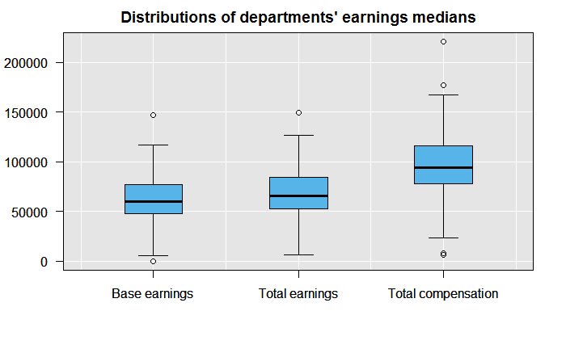

```r
grid(col="white", lty=1) #lty = 1 means solid lines for boxes' borders
# Actually need to plot twice b/c of background coloring trick. Set add = T to "add" this plot to previous one
boxplot(earnings_categ, col = color_blind_palette[2], add=T, las=1, lty=1, main = "Distributions of departments' earnings medians",  pars = list(boxwex = 0.4))
```

#### 2.4 Benefits by department

We will create a summary data frame with Departments as rows and benefits quantities as columns. In other words, each observation consists of a department and a set of descriptive statistics corresponding to that department. We will use salary data for 2015.

```r
benefits_func <- function(dpt) {
  # Function that takes a department name "dpt"" and returns a named vector with the
  # median benefits for that department
  med_medical <- la_salaries_2015$Medical_Dental_Vision[la_salaries_2015$Department == dpt] %>% median(na.rm=T)
  med_pension <- la_salaries_2015$Pension_Contributions[la_salaries_2015$Department == dpt] %>% median(na.rm=T)
  med_ttl_benef <- la_salaries_2015$Total_Benefits[la_salaries_2015$Department == dpt] %>% median(na.rm=T)

  stat_vector <- c(med_medical, med_pension, med_ttl_benef)
  names(stat_vector) <- c("MMed", "MPen", "MTB")
  return(stat_vector)
}
la_salaries_2015_summary_benef <- sapply(departments, benefits_func) %>% t() %>% as.data.frame()
```

#### 2.5 Boxplots of departments’ median benefits

```r
benefits_categ <- list(la_salaries_2015_summary_benef$MMed, la_salaries_2015_summary_benef$MPen, la_salaries_2015_summary_benef$MTB)
names(benefits_categ) <- c("Medical", "Pension", "Total benefits")
boxplot(benefits_categ, las=1,  pars = list(boxwex = 0.4)) # boxwex sets the width of the box
# las = 1 sets both axes horizontal
rect(par("usr")[1], par("usr")[3], par("usr")[2], par("usr")[4], col =
"gray90") # trick to change the background of plotting area, make it look ggplot-ish
```

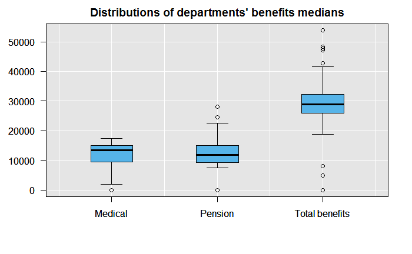

```r
grid(col="white", lty=1) #lty = 1 means solid lines for boxes' borders
# Actually need to plot twice b/c of background coloring trick. Set add = T to "add" this plot to previous one
boxplot(benefits_categ, col = color_blind_palette[2], add=T, las=1, lty=1, main = "Distributions of departments' benefits medians",  pars = list(boxwex = 0.4))
```

### References

1. L.A. County. (2017). *LA County Employee Salaries* [CSV]. Retrieved from https://data.lacounty.gov/Operations/LA-County-Employee-Salaries/8rdv-6nb6
2. ScreechOwl and Ulrich, J. *How to rename a single column in a data.frame?* Retrieved from http://stackoverflow.com/questions/7531868/how-to-rename-a-single-column-in-a-data-frame
3. Schwartz, M. *[R] Background color in plots.* Retrieved from https://stat.ethz.ch/pipermail/r-help/2003-May/033971.html
4. STHDA. *ggplot2 axis ticks : A guide to customize tick marks and labels* Retrieved from http://www.sthda.com/english/wiki/ggplot2-axis-ticks-a-guide-to-customize-tick-marks-and-labels
5. *NBA Scoring (2008)* Retrieved from https://beta.rstudioconnect.com/jjallaire/htmlwidgets-d3heatmap/htmlwidgets-d3heatmap.html